# Descripción general de la base de datos

Cohorte de pacientes con enfermedad renal crónica

Julián David León Torres

2026-10-21

# 1 Descripción del proyecto

Esta base de datos corresponde a una cohorte prospectiva de pacientes con enfermedad renal crónica (ERC) en estadios G2 a G4, seguidos durante 24 meses. Los datos fueron proporcionados por el curso para el desarrollo de las prácticas del Módulo 2.

El análisis de esta base tiene como objetivo desarrollar habilidades en organización reproducible de proyectos analíticos, limpieza de datos, análisis descriptivo, modelado estadístico y generación reproducible de resultados.

# 2 Estructura de la base de datos

La base de datos incluye 300 participantes y 47 variables, organizadas en cuatro bloques: datos basales (sociodemográficos, clínicos y de laboratorio), seguimiento al mes 12, seguimiento al mes 24 y desenlaces.

```
## Participantes: 300
```

```
## Variables: 47
```

```
## Variables disponibles:
```

```
##  [1] "id_estudio"              "fecha_reclutamiento"
##  [3] "edad"                    "sexo"
##  [5] "etnia"                   "nivel_educativo"
##  [7] "procedencia"             "peso_kg_basal"
##  [9] "talla_cm"                "imc_basal"
## [11] "pas_mmhg_basal"          "pad_mmhg_basal"
## [13] "diabetes"                "hipertension"
## [15] "cardiopatia_isquemica"   "tabaquismo_actual"
## [17] "tabaquismo_previo"       "etiologia_erc"
## [19] "estadio_basal"           "tfg_ml_min_basal"
## [21] "creatinina_mg_dl_basal"  "hemoglobina_g_dl_basal"
## [23] "albumina_g_dl_basal"     "proteinuria_mg_g_basal"
## [25] "ieca_o_ara2"             "estatinas"
## [27] "n_medicamentos_totales"  "perdida_seguimiento_m12"
## [29] "motivo_perdida_m12"      "tfg_ml_min_m12"
## [31] "creatinina_mg_dl_m12"    "pas_mmhg_m12"
## [33] "hemoglobina_g_dl_m12"    "albumina_g_dl_m12"
## [35] "peso_kg_m12"             "proteinuria_mg_g_m12"
## [37] "perdida_seguimiento_m24" "motivo_perdida_m24"
## [39] "tfg_ml_min_m24"          "creatinina_mg_dl_m24"
## [41] "pas_mmhg_m24"            "hemoglobina_g_dl_m24"
## [43] "albumina_g_dl_m24"       "peso_kg_m24"
## [45] "proteinuria_mg_g_m24"    "progresion_g5_o_trr"
## [47] "tiempo_seguimiento_dias"
```

## 2.1 Pérdidas de seguimiento

Tabla. Pérdidas de seguimiento por punto de medición

| Punto de seguimiento | N perdidos | % perdidos |
| --- | --- | --- |
| Mes 12 | 37 | 12.3 |
| Mes 24 | 54 | 18.0 |

La pérdida de seguimiento al mes 12 fue de 37 participantes (12.3%), y al mes 24 de 54 (18%).

# 3 Características basales de la cohorte

## 3.1 Descripción general

**Tabla 1. Características basales de la cohorte (n = 300)**

| **Characteristic** | **N = 300**<sup>1</sup> |
| --- | --- |
| Edad (años) | 58 (51–66) |
| Sexo |  |
| Femenino | 157 (52%) |
| Masculino | 143 (48%) |
| Estadio de ERC |  |
| G2 | 69 (23%) |
| G3a | 93 (31%) |
| G3b | 85 (28%) |
| G4 | 53 (18%) |
| Etiología de la ERC |  |
| Diabetica | 115 (38%) |
| Glomerulonefritis | 42 (14%) |
| Hipertensiva | 84 (28%) |
| Otra_desconocida | 32 (11%) |
| Poliquistica | 27 (9.0%) |
| Diabetes mellitus | 122 (41%) |
| Hipertensión arterial | 259 (86%) |
| Cardiopatía isquémica | 56 (19%) |
| TFG estimada (mL/min/1.73m²) | 45 (34–59) |
| Creatinina sérica (mg/dL) | 1.70 (1.22–2.24) |
| Hemoglobina (g/dL) | 11.60 (10.30–12.80) |
| Albúmina sérica (g/dL) | 3.80 (3.50–4.10) |
| Proteinuria (mg/g) | 239 (119–514) |
| PAS (mmHg) | 143 (127–157) |

<sup>1</sup> Median (Q1–Q3); n (%)

## 3.2 Distribución por estadio de ERC

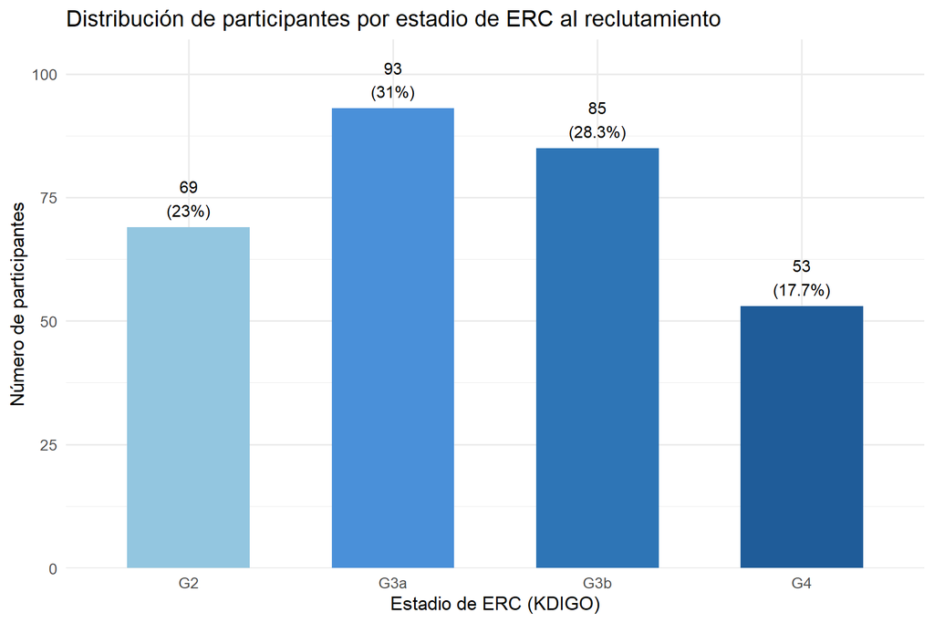

## 3.3 TFG basal por estadio

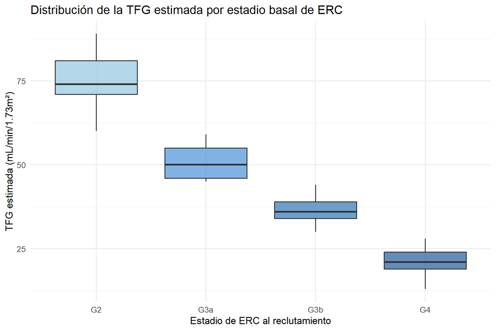

# 4 Datos faltantes

Tabla. Variables con datos faltantes

| Variable | N faltantes | % faltantes |
| --- | --- | --- |
| albumina_g_dl_m24 | 75 | 25.0 |
| proteinuria_mg_g_m24 | 73 | 24.3 |
| hemoglobina_g_dl_m24 | 68 | 22.7 |
| pas_mmhg_m24 | 64 | 21.3 |
| tfg_ml_min_m24 | 54 | 18.0 |
| creatinina_mg_dl_m24 | 54 | 18.0 |
| peso_kg_m24 | 54 | 18.0 |
| hemoglobina_g_dl_m12 | 52 | 17.3 |
| albumina_g_dl_m12 | 51 | 17.0 |
| proteinuria_mg_g_m12 | 50 | 16.7 |
| tfg_ml_min_m12 | 37 | 12.3 |
| creatinina_mg_dl_m12 | 37 | 12.3 |
| pas_mmhg_m12 | 37 | 12.3 |
| peso_kg_m12 | 37 | 12.3 |

# 5 Observaciones sobre la calidad de los datos

Durante la revisión inicial se identificaron las siguientes observaciones que requieren atención en la fase de limpieza de datos:

1. **Valores atípicos en creatinina basal:** La variable `creatinina_mg_dl_basal` presenta valores fuera del rango esperado para la población estudiada. Se revisarán en detalle en la semana de limpieza de datos.
2. **Valores atípicos en peso basal:** La variable `peso_kg_basal` presenta algunos valores inusuales que podrían corresponder a errores de registro.
3. **Datos faltantes en variables de seguimiento:** Las variables de laboratorio en las visitas de mes 12 y mes 24 presentan datos faltantes adicionales (más allá de los esperados por pérdida de seguimiento), probablemente correspondientes a visitas con exámenes incompletos.

Estas observaciones serán abordadas sistemáticamente en la fase de limpieza.

# 6 Información de sesión